# Bilberry cover by area

NO_BBCA_001

Authors

Affiliations

Erik Framstad

Norwegian Institute for Nature Research

Ken Olav Storaunet

Norwegian Institute of Bioeconomy Research

Oliver Snoksrud

Norwegian Institute of Bioeconomy Research

Aud Helen Halbritter

University of Bergen

Published

May 7, 2026

> **Recommended citation**: Framstad, E., Storaunet, K. O., Snoksrud, O. and Halbritter, A. H. 2026. NO_BBCA (ID(s): NO_BBCA) v. 000.001. ecRxiv: https://github.com/NINAnor/ecRxiv/tree/main/indicators/NO_BBCA_001

**TipMetadata**

Table 1: Indicator metadata

| Variable | Value |
| --- | --- |
| Indicator ID | NO_BBCA_001 |
| Indicator Name | NO_BBCA |
| Country | Norway |
| Continent | Europe |
| Ecosystem Condition Typology Class | B1 Biotic compositional characteristic |
| Realm | Terrestrial (T) |
| Biome | T2 Temperate-boreal forests and woodlands biome |
| Ecosystem | T2.1 Boreal/montane forests |
| Year added | 2026 |
| Last update | 2026 |
| Version | 000.001 |
| Version comment | Initial version |
| Normalised | TRUE |
| Spatial aggregation pathway | Aggregate (NFI plots to county/sub-county) - [Scale - Truncate] - Aggregate (geographic region) - Aggregate (national level) |

**TipLog**

- 07 May. 2026 - Original PR

## 2. About the underlying data

This indicator uses data from the Norwegian National Forest Inventory (NFI, *landsskoginventaret*). The bilberry cover by area is recorded for each NFI inventory plot. There are about 12 000 NFI plots in forest ecosystems, distributed on a regular grid, with varying grid density for forest below/above the coniferous forest line and in Finnmark county. The indicator value is an unbiased area-weighted estimate of the bilberry cover for NFI plots in any selected region. All NFI plots are sampled over a 5-year period, with a representative sampling scheme every year, allowing unbiased estimates from data for each year. For this indicator data from each full inventory cycle of 5 years are used, starting in 2010, meaning that results reported for 2024 are based on data from the years 2020-2024. The data are available upon request from NFI.

### 2.2 Sampling design

### 2.3 Original units

The indicator is specified as the percentage (%) of the area covered by bilberry on the NFI plot. In the analyses, this value is converted to a proportion before area weighting, aggregation, and scaling.

### 2.4 Instructions for citing, using and accessing data

The data used for this indicator have been made available by the Norwegian National Forest Inventory under a specific data use agreement of 2025-10-20, between NIBIO and the specified users. Further use of these data requires a separate data user agreement with NIBIO.

## 3. Indicator properties

### 3.1 Ecosystem Condition Typology Class (ECT)

B1 Biotic compositional characteristic

### 3.1.1 Other condition typologies

### 3.2 Ecosystem condition characteristic

### 3.3 Collinearities with other indicators

### 3.4 Impact factors

### 3.5 Spatial aggregation

The spatial aggregation pathway is Aggregate (NFI plots to county/sub-county) – [Scale – Truncate] – Aggregate (geographic region) – Aggregate (national level). For each NFI plot we first convert bilberry cover from percent to proportion and create `indicator_continuous_weighted = indicator_cover * au_areal`. Non-scaled indicator values for each reporting period are calculated separately for each geographic unit as area-weighted arithmetic means of all NFI plots within that unit: sum of `indicator_continuous_weighted` divided by sum of `au_areal`. This is done for counties or sub-counties, regions, and at national level. Scaling and truncation are applied only after these non-scaled county or sub-county aggregates have been calculated: each county or sub-county is scaled against its own lower reference level X0 (0% cover) and upper reference level X100 using a linear scaling function, and values above 1 are truncated to 1 at that step (not after regional or national aggregation). Regional and national scaled point estimates are area-weighted means of the already scaled county or sub-county values, using each county or sub-county’s represented area as weight. Non-scaled regional and national point estimates are still calculated directly from all plots within each region or the whole country.

## 4. Reference condition and levels

### 4.1 Reference condition

### 4.2 Reference levels

#### 4.2.1 Spatial resolution and validity

Reference levels are defined at county or sub-county resolution, not as one national value. Scaling is therefore applied to area-weighted non-scaled indicator values that have first been aggregated to the matching county or sub-county unit. Regional and national reporting uses area-weighted aggregation of these scaled county or sub-county values rather than one common X100 for the aggregated non-scaled value. The indicator should not be interpreted at finer spatial resolution than the county or sub-county reference levels allow.

## 6. References

## 7. Import and prepare datasets

The bilberry cover by area is recorded for each NFI plot in the LSK export. For this indicator we use data from each full 5-year inventory cycle, starting in 2010.

**Load data**

```r
# Load main data file
# This export wraps each physical line in an extra pair of double quotes, so a
# single read_csv() sees one column spanning the whole file. Read once as one
# character column per line (readr unwraps the outer quotes), then parse the
# inner CSV text.
lsk_inner_csv <- read_csv(
  here("data/LSK_data_okologisk_tilstand_2026.csv"),
  col_names = FALSE,
  show_col_types = FALSE,
  locale = locale(encoding = "UTF-8"),
  col_types = cols(.default = col_character())
) |>
  pull(1) |>
  paste(collapse = "\n")

lsk_data_raw <- read_csv(
  I(lsk_inner_csv),
  show_col_types = FALSE,
  locale = locale(encoding = "UTF-8")
) |>
  clean_names()
```

## 8. Spatial units

Aggregated indicator values should not be applied for spatial units finer than those that allow reliable estimates, e.g., regions.

## 9. Analyses

### 9.1 Prepare data and create derived variables

This section prepares the NFI plot data for calculating the indicator.

First we define the 5-year reporting periods that match the temporal structure of the indicator.

**Define reporting periods**

```r
# Define multiple 5-year reporting periods starting from 2010
reporting_periods <- list(
  "2010-2014" = 2010:2014,
  "2015-2019" = 2015:2019,
  "2020-2024" = 2020:2024
)
```

Next we filter the raw dataset to include both productive and unproductive forest plots (`arealtype` 1 and 12), remove records missing in the `blaabaer_gjsn` variable, and standardise the fylke names. NFI bilberry cover is recorded on a 0-100 percent scale and is converted to a proportion before aggregation and scaling. Area-weighted values are created `indicator_continuous_weighted = indicator_cover * au_areal` (section 9.1).

**Create derived variables**

```r
lsk_data <- lsk_data_raw |>
  filter(
    # productive and unproductive forest plots
    arealtype %in% c(1, 12)
  ) |>
  # remove records with missing data on bilberry cover
  filter(!is.na(blaabaer_gjsn)) |>
  mutate(
    fylke_name = region_fylke |>
      stringr::str_remove("^\\d+-\\d+\\s+") |>
      stringr::str_remove("^\\d+\\s*") |>
      stringr::str_squish(),
    county_part = assign_bbca_county_part(fylke_name),
    fylke_name_clean = stringi::stri_trans_general(
      stringr::str_squish(
        tolower(
          stringr::str_replace_all(
            normalize_county_parts(fylke_name),
            "[0-9.-]",
            " "
          )
        )
      ),
      "Latin-ASCII"
    ),
    region_code = assign_region_code(fylke_name_clean),
    region_name = assign_region_name(region_code),

    indicator_cover = blaabaer_gjsn / 100,
    indicator_continuous_weighted = indicator_cover * au_areal
  )
```

Finally, we retain only the columns required for subsequent aggregation and reporting.

**Select downstream fields**

```r
lsk_data <- lsk_data |>
  dplyr::select(
    sesong,
    au_areal,
    arealtype,
    region_code,
    region_name,
    county_part,
    fylke_name,
    fylke_name_clean,
    blaabaer_gjsn,
    indicator_continuous_weighted
  )
```

### 9.2 Calculate non-scaled area-weighted indicator values

For each reporting period, we calculate non-scaled indicator values separately for counties or sub-counties, regions, and the whole country. Within each geographic unit, the point estimate is the area-weighted arithmetic mean of all NFI plots in that unit: sum of `indicator_continuous_weighted` divided by sum of `au_areal`. County or sub-county estimates use the plot-level `fylke_name` field; regional estimates use `region_code`; the national estimate uses all plots in the period.

**Calculate non-scaled values**

```r
 bbca_results <- purrr::imap(
   reporting_periods,
   ~ calculate_period_indicators(lsk_data, .y, .x)
 ) |>
   purrr::compact()

 bbca_results_county_all_periods   <- purrr::map_dfr(bbca_results, "county")
 bbca_results_region_all_periods   <- purrr::map_dfr(bbca_results, "region")
 bbca_results_national_all_periods <- purrr::map_dfr(bbca_results, "national")
```

### 9.3 Bootstrap draws per county

For each county and period, NFI plots are resampled with replacement 1000 times. Each replicate computes the area-weighted mean non-scaled indicator value, giving a distribution of 1000 draws per county.

**Bootstrap draws per county (1000 per county per period)**

```r
county_draws_long <- purrr::imap_dfr(bbca_results, function(period_result, period_name) {
  county_meta <- period_result$county |>
    dplyr::select(fylke_name, county_part, total_area, region_code)

  purrr::imap_dfr(
    split(period_result$data, period_result$data$fylke_name),
    function(county_data, county_name) {
      boot <- bootstrap_indicator(county_data, n_bootstrap = 1000)
      dplyr::tibble(
        period           = period_name,
        fylke_name       = county_name,
        sim_id           = seq_along(boot$draws),
        non_scaled_value = boot$draws
      )
    }
  ) |>
    dplyr::left_join(county_meta, by = "fylke_name")
})
```

The table below (Table 2) summarises the non-scaled bootstrap draws for the latest reporting period (`2020-2024`): the median area-weighted bilberry cover per county or sub-county.

Table 2: Non-scaled, area-weighted bilberry cover by county or sub-county for reporting period 2020–2024 (median of 1000 bootstrap draws).

| Period | County | Sub-county | Region | Non-scaled value (proportion) | Non-scaled value (%) | Total area (ha) | Number of plots |
| --- | --- | --- | --- | --- | --- | --- | --- |
| 2020-2024 | Buskerud SØ | BuS | Øst | 0.1199 | 11.99 | 592223 | 700 |
| 2020-2024 | Buskerud V | BuV | Øst | 0.0808 | 8.08 | 163220 | 158 |
| 2020-2024 | Hedmark N | HeN | Øst | 0.0729 | 7.29 | 690677 | 693 |
| 2020-2024 | Hedmark S | HeS | Øst | 0.1323 | 13.23 | 1003158 | 1208 |
| 2020-2024 | Oppland NV | OpN | Øst | 0.0856 | 8.56 | 393487 | 391 |
| 2020-2024 | Oppland SØ | OpS | Øst | 0.1375 | 13.75 | 583673 | 687 |
| 2020-2024 | Oslo og Akershus | OA | Øst | 0.1304 | 13.04 | 344363 | 426 |
| 2020-2024 | Vestfold | Ve | Øst | 0.0635 | 6.35 | 140773 | 176 |
| 2020-2024 | Østfold | Øs | Øst | 0.0943 | 9.43 | 270371 | 327 |
| 2020-2024 | Aust-Agder | AA | Sør | 0.1082 | 10.82 | 479098 | 552 |
| 2020-2024 | Telemark NV | TeN | Sør | 0.1105 | 11.05 | 441627 | 474 |
| 2020-2024 | Telemark SØ | TeS | Sør | 0.1059 | 10.59 | 360315 | 429 |
| 2020-2024 | Vest-Agder | VA | Sør | 0.1117 | 11.17 | 404570 | 441 |
| 2020-2024 | Hordaland | Ho | Vest | 0.0851 | 8.51 | 441025 | 501 |
| 2020-2024 | Rogaland | Ro | Vest | 0.1234 | 12.34 | 248090 | 252 |
| 2020-2024 | Sogn og Fjordane | SF | Vest | 0.0894 | 8.94 | 405367 | 451 |
| 2020-2024 | Møre og Romsdal | MR | Midt | 0.1050 | 10.50 | 433919 | 488 |
| 2020-2024 | Nord-Trøndelag | NT | Midt | 0.0963 | 9.63 | 946459 | 1123 |
| 2020-2024 | Sør-Trøndelag | ST | Midt | 0.1210 | 12.10 | 686018 | 752 |
| 2020-2024 | Finnmark | Fi | Nord | 0.0292 | 2.92 | 1026679 | 237 |
| 2020-2024 | Nordland N | NoN | Nord | 0.0515 | 5.15 | 633879 | 672 |
| 2020-2024 | Nordland S | NoS | Nord | 0.0844 | 8.44 | 496076 | 514 |
| 2020-2024 | Troms | Tr | Nord | 0.0414 | 4.14 | 716327 | 778 |

### 9.4 Scale indicator values and aggregate to regional and national levels

County or sub-county reference values are imported manually.

**Reference values by county or sub-county**

```r
# X100 reference values (% bilberry cover by area)
bbca_reference_values <- dplyr::tibble(
  county_part = c(
    "Øs", "OA", "HeS", "HeN", "OpS", "OpN", "BuS", "BuV", "Ve",
    "TeS", "TeN", "AA", "VA", "Ro", "Ho", "SF", "MR", "ST", "NT",
    "NoS", "NoN", "Tr", "Fi"
  ),
  x100_pct = c(
    12.5, 12.5, 12.5, 10, 12.5, 10, 12.5, 10, 12.5,
    12.5, 10, 12.5, 12.5, 12.5, 12.5, 12.5, 12.5, 12.5, 12.5,
    10, 5, 5, 2.5
  )
) |>
  dplyr::mutate(x100 = x100_pct / 100)

x0 <- 0
county_reference <- bbca_reference_values |>
  dplyr::select(county_part, x100)
```

Each county’s 1000 non-scaled draws from section 9.3 are scaled with `ecTools::ec_normalise()` (linear, X0 = 0, county-specific X100). Figure 1 shows the mapping for each sub-county.

**Scale county draws; derive county uncertainty and feed ec_upscale**

```r
county_draws_scaled <- county_draws_long |>
  dplyr::inner_join(county_reference, by = "county_part") |>
  dplyr::mutate(
    scaled_value = ec_normalise(
      non_scaled_value,
      x0 = 0,
      x100 = x100,
      fun = "linear"
    ),
    nation = "National"
  )

# Summarise scaled draws per county → county-level results table (10.1)
county_scaled_with_uncertainty <- county_draws_scaled |>
  dplyr::group_by(period, fylke_name, county_part, total_area) |>
  dplyr::summarise(
    median = median(scaled_value),
    p_025  = as.numeric(quantile(scaled_value, 0.025)),
    p_25   = as.numeric(quantile(scaled_value, 0.25)),
    p_75   = as.numeric(quantile(scaled_value, 0.75)),
    p_975  = as.numeric(quantile(scaled_value, 0.975)),
    .groups = "drop"
  ) |>
  dplyr::left_join(
    bbca_results_county_all_periods |> dplyr::select(period, fylke_name, n_plots),
    by = c("period", "fylke_name")
  )
```

**Normalisation diagnostic figure**

```r
norm_plot_data <- county_draws_scaled |>
  dplyr::group_by(county_part) |>
  dplyr::slice_sample(n = 100) |>
  dplyr::ungroup()

bbca_norm_plot <- ec_norm_plot(norm_plot_data$non_scaled_value, norm_plot_data$scaled_value) +
  ggplot2::facet_wrap(~ norm_plot_data$county_part, scales = "free_x") +
  ggplot2::labs(
    x = "Bilberry cover (proportion)",
    y = "Scaled indicator value"
  ) +
  ggplot2::theme(axis.text = ggplot2::element_text(size = 9))
bbca_norm_plot$layers[[1]]$aes_params$size <- 3

ggsave(
  filename = here::here("img/bbca_norm_plot.png"),
  plot     = bbca_norm_plot,
  scale    = 1.5
)
```

**Normalisation diagnostic figure**

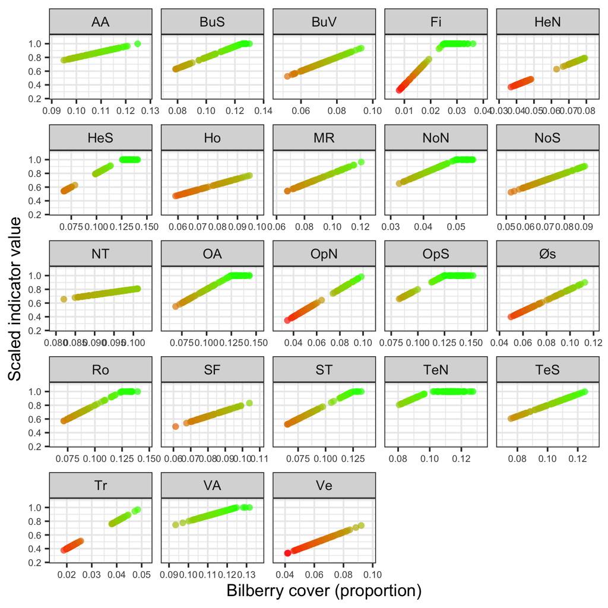

Figure 1: Linear normalisation of bilberry cover proportion to indicator values (0–1), one panel per sub-county reference unit. Points are 100 sampled bootstrap draws per unit.

```r
bbca_norm_plot
```

The scaled draws are then passed to `ecTools::ec_upscale()`, which propagates uncertainty through the spatial hierarchy. For each of 1000 Monte Carlo iterations, one draw is sampled per county and the area-weighted mean gives one regional value; a second `ec_upscale()` call repeats this from regions to national level.

**ec_upscale: county to region**

```r
bbca_mc_regional <- ecTools::ec_upscale(
  data        = county_draws_scaled,
  variable    = scaled_value,
  weight      = total_area,
  start_units = fylke_name,
  end_units   = region_code,
  year        = period,
  end_units_name = "region_code",
  n = 1000
)
saveRDS(bbca_mc_regional, here::here("data/bbca_mc_regional.rds"))
```

**ec_upscale: region to national**

```r
# Region-level area weights (sum of county total_area within each region)
region_area_weights <- county_draws_scaled |>
  dplyr::distinct(period, fylke_name, total_area, region_code) |>
  dplyr::group_by(period, region_code) |>
  dplyr::summarise(region_area = sum(total_area), .groups = "drop")

bbca_mc_regional_for_national <- bbca_mc_regional |>
  dplyr::left_join(region_area_weights, by = c("period", "region_code")) |>
  dplyr::mutate(nation = "National")

bbca_mc_national <- ecTools::ec_upscale(
  data        = bbca_mc_regional_for_national,
  variable    = sampled_mean,
  weight      = region_area,
  start_units = region_code,
  end_units   = nation,
  year        = period,
  end_units_name = "nation",
  n = 1000
)
saveRDS(bbca_mc_national, here::here("data/bbca_mc_national.rds"))
```

**Combine regional and national MC draws; build summary tables**

```r
bbca_mc_combined <- dplyr::bind_rows(
  bbca_mc_regional |> dplyr::select(period, region = region_code, sampled_mean),
  bbca_mc_national |> dplyr::select(period, region = nation,      sampled_mean)
)

# County point estimates (non-bootstrapped) scaled for the truncation check
county_scaled_all_periods <- bbca_results_county_all_periods |>
  dplyr::left_join(county_reference, by = "county_part") |>
  dplyr::filter(!is.na(x100)) |>
  dplyr::mutate(
    scaled_value = ec_normalise(indicator_value, x0 = x0, x100 = x100, fun = "linear")
  )

# Point-estimate summaries (median of MC draws) used in the truncation check
region_scaled_agg_all_periods <- bbca_mc_regional |>
  dplyr::group_by(period, region_code) |>
  dplyr::summarise(scaled_value = median(sampled_mean), .groups = "drop") |>
  dplyr::mutate(region_name = assign_region_name(region_code))

national_scaled_agg_all_periods <- bbca_mc_national |>
  dplyr::group_by(period) |>
  dplyr::summarise(scaled_value = median(sampled_mean), .groups = "drop") |>
  dplyr::mutate(region = "National")

# Uncertainty summaries for the results tables (section 10)
region_scaled_agg_with_uncertainty <- bbca_mc_regional |>
  dplyr::group_by(period, region_code) |>
  dplyr::summarise(
    median = median(sampled_mean),
    p_025  = as.numeric(quantile(sampled_mean, 0.025)),
    p_25   = as.numeric(quantile(sampled_mean, 0.25)),
    p_75   = as.numeric(quantile(sampled_mean, 0.75)),
    p_975  = as.numeric(quantile(sampled_mean, 0.975)),
    .groups = "drop"
  ) |>
  dplyr::mutate(region_name = assign_region_name(region_code)) |>
  dplyr::left_join(
    bbca_results_region_all_periods |> dplyr::select(period, region_code, total_area, n_plots),
    by = c("period", "region_code")
  )

national_scaled_agg_with_uncertainty <- bbca_mc_national |>
  dplyr::group_by(period) |>
  dplyr::summarise(
    median = median(sampled_mean),
    p_025  = as.numeric(quantile(sampled_mean, 0.025)),
    p_25   = as.numeric(quantile(sampled_mean, 0.25)),
    p_75   = as.numeric(quantile(sampled_mean, 0.75)),
    p_975  = as.numeric(quantile(sampled_mean, 0.975)),
    .groups = "drop"
  ) |>
  dplyr::mutate(region = "National") |>
  dplyr::left_join(
    bbca_results_national_all_periods |> dplyr::select(period, total_area, n_plots),
    by = "period"
  )

# Truncation check across all spatial levels
truncation_summary <- dplyr::bind_rows(
  county_scaled_all_periods |>
    dplyr::left_join(
      bbca_reference_values |> dplyr::select(county_part, reference_value_pct = x100_pct),
      by = "county_part"
    ) |>
    dplyr::mutate(
      level = "County",
      exceeds_threshold = indicator_value > x100,
      original_value_pct = round(indicator_value * 100, 2),
      region_code = NA_character_,
      region_name = NA_character_
    ) |>
    dplyr::select(period, level, region_code, region_name, fylke_name,
                  reference_value_pct, exceeds_threshold, original_value_pct),
  region_scaled_agg_all_periods |>
    dplyr::left_join(
      bbca_results_region_all_periods |> dplyr::select(period, region_code, indicator_value),
      by = c("period", "region_code")
    ) |>
    dplyr::mutate(
      level = "Region",
      exceeds_threshold = scaled_value >= 1,
      original_value_pct = round(indicator_value * 100, 2),
      reference_value_pct = NA_real_,
      fylke_name = NA_character_
    ) |>
    dplyr::select(period, level, region_code, region_name, fylke_name,
                  reference_value_pct, exceeds_threshold, original_value_pct),
  national_scaled_agg_all_periods |>
    dplyr::left_join(
      bbca_results_national_all_periods |> dplyr::select(period, indicator_value),
      by = "period"
    ) |>
    dplyr::mutate(
      level = "National",
      exceeds_threshold = scaled_value >= 1,
      original_value_pct = round(indicator_value * 100, 2),
      reference_value_pct = NA_real_,
      region_code = NA_character_,
      region_name = "National",
      fylke_name = NA_character_
    ) |>
    dplyr::select(period, level, region_code, region_name, fylke_name,
                  reference_value_pct, exceeds_threshold, original_value_pct)
)

truncation_counts <- truncation_summary |>
  dplyr::group_by(period, level) |>
  dplyr::summarise(
    n_total = dplyr::n(),
    n_exceeding_reference = sum(exceeds_threshold, na.rm = TRUE),
    pct_exceeding_reference = round(100 * n_exceeding_reference / n_total, 1),
    .groups = "drop"
  )

truncated_values <- truncation_summary |>
  dplyr::filter(exceeds_threshold) |>
  dplyr::arrange(period, level, dplyr::desc(original_value_pct))
```

At county or sub-county level, truncation is evaluated by comparing the non-scaled point estimate to the matching X100. At regional and national level, the tables report cases where the `ec_upscale()` median equals 1. The following tables summarise how often truncation occurred in each period and list the affected units.

**Report truncation**

```r
truncation_counts |>
  dplyr::rename(
    Period = period,
    Level = level,
    `Total` = n_total,
    `Exceeding reference` = n_exceeding_reference,
    `% Exceeding reference` = pct_exceeding_reference
  ) |>
  gt::gt() |>
  gt::tab_style(
    style = gt::cell_text(weight = "bold"),
    locations = gt::cells_column_labels()
  ) |>
  gt::fmt_number(
    columns = `% Exceeding reference`,
    decimals = 1
  )
```

| Period | Level | Total | Exceeding reference | % Exceeding reference |
| --- | --- | --- | --- | --- |
| 2010-2014 | County | 23 | 0 | 0.0 |
| 2010-2014 | National | 1 | 0 | 0.0 |
| 2010-2014 | Region | 5 | 0 | 0.0 |
| 2015-2019 | County | 23 | 1 | 4.3 |
| 2015-2019 | National | 1 | 0 | 0.0 |
| 2015-2019 | Region | 5 | 0 | 0.0 |
| 2020-2024 | County | 23 | 6 | 26.1 |
| 2020-2024 | National | 1 | 0 | 0.0 |
| 2020-2024 | Region | 5 | 0 | 0.0 |

**Report truncation**

```r
if (nrow(truncated_values) > 0) {
  truncated_values |>
    dplyr::mutate(
      location = dplyr::case_when(
        level == "County" ~ fylke_name,
        level == "Region" ~ region_name,
        level == "National" ~ "National",
        TRUE ~ NA_character_
      )
    ) |>
    dplyr::select(
      period,
      level,
      location,
      reference_value_pct,
      original_value_pct
    ) |>
    dplyr::rename(
      Period = period,
      Level = level,
      Location = location,
      `Reference (%)` = reference_value_pct,
      `Original Value (%)` = original_value_pct
    ) |>
    gt::gt() |>
    gt::tab_style(
      style = gt::cell_text(weight = "bold"),
      locations = gt::cells_column_labels()
    ) |>
    gt::fmt_number(
      columns = c(`Reference (%)`, `Original Value (%)`),
      decimals = 1
    )
} else {
  cat("\nNo values exceeded their reference and required truncation.\n")
}
```

| Period | Level | Location | Reference (%) | Original Value (%) |
| --- | --- | --- | --- | --- |
| 2015-2019 | County | Telemark NV | 10.0 | 11.6 |
| 2020-2024 | County | Oppland SØ | 12.5 | 13.8 |
| 2020-2024 | County | Hedmark S | 12.5 | 13.2 |
| 2020-2024 | County | Oslo og Akershus | 12.5 | 13.1 |
| 2020-2024 | County | Telemark NV | 10.0 | 11.1 |
| 2020-2024 | County | Nordland N | 5.0 | 5.1 |
| 2020-2024 | County | Finnmark | 2.5 | 2.9 |

## 10. Results

The following tables present scaled indicator results at county or sub-county, regional, and national scales for each reporting period. Tables report the median as the indicator value, with an approximate 95% interval (2.5% and 97.5% quantiles) and an approximate interquartile range (25% and 75% quantiles).

The time series below (Figure 2) summarises regional and national values.

**Time series of indicator values by region and period**

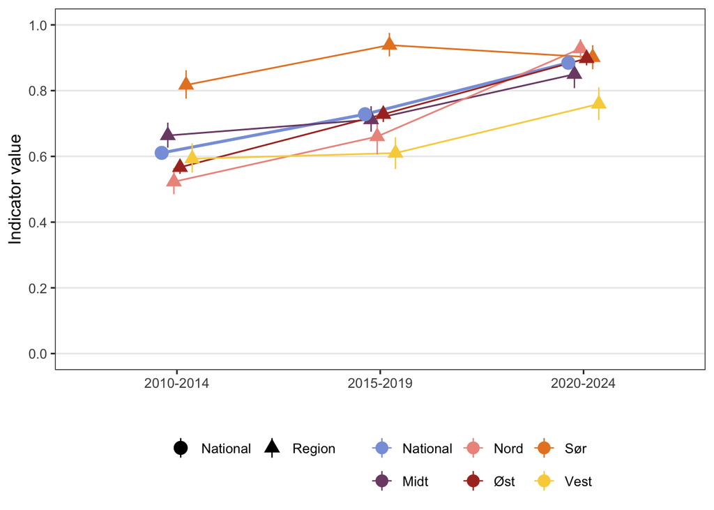

Figure 2: Indicator values for bilberry cover by area by region and reporting period. Points show the MC median; error bars are 95% credible intervals from the Monte Carlo propagation. National values use filled circles and a thicker line.

```r
bbca_region_labels <- c(
  "1" = "Øst", "2" = "Sør", "3" = "Vest",
  "4" = "Midt", "5" = "Nord", "National" = "National"
)
bbca_region_levels <- c("National", "Midt", "Nord", "Øst", "Sør", "Vest")
bbca_region_cols <- setNames(
  MetBrewer::met.brewer("Archambault", n = length(bbca_region_levels)),
  bbca_region_levels
)

bbca_plot_data <- bbca_mc_combined |>
  dplyr::mutate(
    region_name = dplyr::recode(region, !!!bbca_region_labels),
    series_type = dplyr::if_else(region == "National", "National", "Region")
  ) |>
  dplyr::group_by(period, region_name, series_type) |>
  dplyr::summarise(
    median = median(sampled_mean),
    p_025  = as.numeric(quantile(sampled_mean, 0.025)),
    p_975  = as.numeric(quantile(sampled_mean, 0.975)),
    .groups = "drop"
  ) |>
  dplyr::mutate(region_name = factor(region_name, levels = bbca_region_levels))

ggplot2::ggplot(bbca_plot_data,
                ggplot2::aes(x = period, y = median, colour = region_name, group = region_name)) +
  ggplot2::geom_line(
    ggplot2::aes(linewidth = series_type),
    position = ggplot2::position_dodge(width = 0.18)
  ) +
  ggplot2::geom_pointrange(
    ggplot2::aes(ymin = p_025, ymax = p_975, shape = series_type),
    size = 0.8, linewidth = 0.45,
    position = ggplot2::position_dodge(width = 0.18)
  ) +
  ggplot2::scale_colour_manual(values = bbca_region_cols, name = NULL) +
  ggplot2::scale_shape_manual(values = c(National = 19, Region = 17), name = NULL) +
  ggplot2::scale_linewidth_manual(values = c(National = 1, Region = 0.55), guide = "none") +
  ggplot2::scale_y_continuous(limits = c(0, 1), breaks = seq(0, 1, 0.2)) +
  ggplot2::theme_bw(base_size = 12) +
  ggplot2::theme(
    legend.position    = "bottom",
    legend.box         = "horizontal",
    panel.grid.minor   = ggplot2::element_blank(),
    panel.grid.major.x = ggplot2::element_blank()
  ) +
  ggplot2::guides(
    colour = ggplot2::guide_legend(nrow = 2,
                                   override.aes = list(size = 0.7, linewidth = 0.45)),
    shape  = ggplot2::guide_legend(override.aes = list(size = 0.8, linewidth = 0.45))
  ) +
  ggplot2::labs(y = "Indicator value", x = "")
```

### 10.1 County-level results (scaled with uncertainty)

Table 3: County or sub-county indicator values for bilberry cover by area by reporting period. Values are scaled to 0–1 using county-specific X0 and X100 via ec_normalise(). Uncertainty is derived from 1000 bootstrap draws scaled with the same function (section 9.3–9.4). The median is reported as the indicator value, with approximate 95% and interquartile intervals from the scaled draw distribution.

| ECT | Indicator | ID | Accounting area | Region | Sub-county | Ecosystem | Reporting period | Indicator value | 95% CI | 50% CI | Number of plots |
| --- | --- | --- | --- | --- | --- | --- | --- | --- | --- | --- | --- |
| B1 | Bilberry cover by area | NO_BBCA_001 | Oslo og Akershus | Øst | OA | Boreal/montane forests | 2010-2014 | 0.66 | 0.58 - 0.73 | 0.63 - 0.68 | 425 |
| B1 | Bilberry cover by area | NO_BBCA_001 | Vestfold | Øst | Ve | Boreal/montane forests | 2010-2014 | 0.46 | 0.36 - 0.58 | 0.42 - 0.5 | 171 |
| B1 | Bilberry cover by area | NO_BBCA_001 | Østfold | Øst | Øs | Boreal/montane forests | 2010-2014 | 0.46 | 0.4 - 0.52 | 0.44 - 0.48 | 325 |
| B1 | Bilberry cover by area | NO_BBCA_001 | Hordaland | Vest | Ho | Boreal/montane forests | 2010-2014 | 0.53 | 0.47 - 0.6 | 0.51 - 0.55 | 505 |
| B1 | Bilberry cover by area | NO_BBCA_001 | Rogaland | Vest | Ro | Boreal/montane forests | 2010-2014 | 0.67 | 0.57 - 0.77 | 0.63 - 0.7 | 258 |
| B1 | Bilberry cover by area | NO_BBCA_001 | Sogn og Fjordane | Vest | SF | Boreal/montane forests | 2010-2014 | 0.62 | 0.54 - 0.69 | 0.59 - 0.64 | 466 |
| B1 | Bilberry cover by area | NO_BBCA_001 | Møre og Romsdal | Midt | MR | Boreal/montane forests | 2010-2014 | 0.62 | 0.54 - 0.7 | 0.6 - 0.65 | 498 |
| B1 | Bilberry cover by area | NO_BBCA_001 | Finnmark | Nord | Fi | Boreal/montane forests | 2010-2014 | 0.41 | 0.32 - 0.49 | 0.38 - 0.43 | 220 |
| B1 | Bilberry cover by area | NO_BBCA_001 | Troms | Nord | Tr | Boreal/montane forests | 2010-2014 | 0.44 | 0.38 - 0.52 | 0.42 - 0.47 | 792 |
| B1 | Bilberry cover by area | NO_BBCA_001 | Aust-Agder | NA | AA | Boreal/montane forests | 2010-2014 | 0.81 | 0.73 - 0.9 | 0.79 - 0.84 | 551 |
| B1 | Bilberry cover by area | NO_BBCA_001 | Buskerud SØ | NA | BuS | Boreal/montane forests | 2010-2014 | 0.68 | 0.63 - 0.73 | 0.66 - 0.7 | 701 |
| B1 | Bilberry cover by area | NO_BBCA_001 | Buskerud V | NA | BuV | Boreal/montane forests | 2010-2014 | 0.67 | 0.57 - 0.78 | 0.63 - 0.71 | 157 |
| B1 | Bilberry cover by area | NO_BBCA_001 | Hedmark N | NA | HeN | Boreal/montane forests | 2010-2014 | 0.43 | 0.39 - 0.47 | 0.41 - 0.44 | 690 |
| B1 | Bilberry cover by area | NO_BBCA_001 | Hedmark S | NA | HeS | Boreal/montane forests | 2010-2014 | 0.57 | 0.53 - 0.61 | 0.55 - 0.58 | 1211 |
| B1 | Bilberry cover by area | NO_BBCA_001 | Nord-Trøndelag | NA | NT | Boreal/montane forests | 2010-2014 | 0.74 | 0.68 - 0.79 | 0.72 - 0.76 | 1126 |
| B1 | Bilberry cover by area | NO_BBCA_001 | Nordland N | NA | NoN | Boreal/montane forests | 2010-2014 | 0.75 | 0.67 - 0.84 | 0.72 - 0.78 | 680 |
| B1 | Bilberry cover by area | NO_BBCA_001 | Nordland S | NA | NoS | Boreal/montane forests | 2010-2014 | 0.64 | 0.56 - 0.72 | 0.61 - 0.67 | 515 |
| B1 | Bilberry cover by area | NO_BBCA_001 | Oppland NV | NA | OpN | Boreal/montane forests | 2010-2014 | 0.44 | 0.37 - 0.51 | 0.42 - 0.46 | 385 |
| B1 | Bilberry cover by area | NO_BBCA_001 | Oppland SØ | NA | OpS | Boreal/montane forests | 2010-2014 | 0.72 | 0.66 - 0.79 | 0.7 - 0.74 | 692 |
| B1 | Bilberry cover by area | NO_BBCA_001 | Sør-Trøndelag | NA | ST | Boreal/montane forests | 2010-2014 | 0.58 | 0.53 - 0.64 | 0.57 - 0.61 | 753 |
| B1 | Bilberry cover by area | NO_BBCA_001 | Telemark NV | NA | TeN | Boreal/montane forests | 2010-2014 | 0.88 | 0.8 - 0.98 | 0.85 - 0.92 | 478 |
| B1 | Bilberry cover by area | NO_BBCA_001 | Telemark SØ | NA | TeS | Boreal/montane forests | 2010-2014 | 0.68 | 0.59 - 0.76 | 0.65 - 0.7 | 434 |
| B1 | Bilberry cover by area | NO_BBCA_001 | Vest-Agder | NA | VA | Boreal/montane forests | 2010-2014 | 0.87 | 0.77 - 0.97 | 0.83 - 0.91 | 435 |
| B1 | Bilberry cover by area | NO_BBCA_001 | Oslo og Akershus | Øst | OA | Boreal/montane forests | 2015-2019 | 0.82 | 0.73 - 0.91 | 0.79 - 0.85 | 424 |
| B1 | Bilberry cover by area | NO_BBCA_001 | Vestfold | Øst | Ve | Boreal/montane forests | 2015-2019 | 0.55 | 0.42 - 0.68 | 0.51 - 0.59 | 174 |
| B1 | Bilberry cover by area | NO_BBCA_001 | Østfold | Øst | Øs | Boreal/montane forests | 2015-2019 | 0.55 | 0.47 - 0.64 | 0.52 - 0.58 | 322 |
| B1 | Bilberry cover by area | NO_BBCA_001 | Hordaland | Vest | Ho | Boreal/montane forests | 2015-2019 | 0.55 | 0.49 - 0.62 | 0.53 - 0.58 | 493 |
| B1 | Bilberry cover by area | NO_BBCA_001 | Rogaland | Vest | Ro | Boreal/montane forests | 2015-2019 | 0.69 | 0.58 - 0.79 | 0.65 - 0.72 | 247 |
| B1 | Bilberry cover by area | NO_BBCA_001 | Sogn og Fjordane | Vest | SF | Boreal/montane forests | 2015-2019 | 0.62 | 0.55 - 0.7 | 0.59 - 0.64 | 452 |
| B1 | Bilberry cover by area | NO_BBCA_001 | Møre og Romsdal | Midt | MR | Boreal/montane forests | 2015-2019 | 0.67 | 0.58 - 0.76 | 0.64 - 0.7 | 492 |
| B1 | Bilberry cover by area | NO_BBCA_001 | Finnmark | Nord | Fi | Boreal/montane forests | 2015-2019 | 0.65 | 0.51 - 0.83 | 0.6 - 0.71 | 239 |
| B1 | Bilberry cover by area | NO_BBCA_001 | Troms | Nord | Tr | Boreal/montane forests | 2015-2019 | 0.43 | 0.39 - 0.48 | 0.42 - 0.45 | 775 |
| B1 | Bilberry cover by area | NO_BBCA_001 | Aust-Agder | NA | AA | Boreal/montane forests | 2015-2019 | 0.91 | 0.83 - 0.98 | 0.88 - 0.93 | 553 |
| B1 | Bilberry cover by area | NO_BBCA_001 | Buskerud SØ | NA | BuS | Boreal/montane forests | 2015-2019 | 0.82 | 0.75 - 0.9 | 0.8 - 0.85 | 695 |
| B1 | Bilberry cover by area | NO_BBCA_001 | Buskerud V | NA | BuV | Boreal/montane forests | 2015-2019 | 0.63 | 0.53 - 0.76 | 0.6 - 0.67 | 156 |
| B1 | Bilberry cover by area | NO_BBCA_001 | Hedmark N | NA | HeN | Boreal/montane forests | 2015-2019 | 0.44 | 0.4 - 0.49 | 0.43 - 0.46 | 690 |
| B1 | Bilberry cover by area | NO_BBCA_001 | Hedmark S | NA | HeS | Boreal/montane forests | 2015-2019 | 0.84 | 0.78 - 0.9 | 0.82 - 0.86 | 1207 |
| B1 | Bilberry cover by area | NO_BBCA_001 | Nord-Trøndelag | NA | NT | Boreal/montane forests | 2015-2019 | 0.75 | 0.69 - 0.8 | 0.72 - 0.77 | 1123 |
| B1 | Bilberry cover by area | NO_BBCA_001 | Nordland N | NA | NoN | Boreal/montane forests | 2015-2019 | 0.88 | 0.79 - 0.97 | 0.85 - 0.91 | 674 |
| B1 | Bilberry cover by area | NO_BBCA_001 | Nordland S | NA | NoS | Boreal/montane forests | 2015-2019 | 0.73 | 0.64 - 0.83 | 0.7 - 0.76 | 514 |
| B1 | Bilberry cover by area | NO_BBCA_001 | Oppland NV | NA | OpN | Boreal/montane forests | 2015-2019 | 0.54 | 0.46 - 0.62 | 0.51 - 0.57 | 385 |
| B1 | Bilberry cover by area | NO_BBCA_001 | Oppland SØ | NA | OpS | Boreal/montane forests | 2015-2019 | 0.97 | 0.9 - 1 | 0.95 - 1 | 688 |
| B1 | Bilberry cover by area | NO_BBCA_001 | Sør-Trøndelag | NA | ST | Boreal/montane forests | 2015-2019 | 0.69 | 0.63 - 0.76 | 0.66 - 0.71 | 752 |
| B1 | Bilberry cover by area | NO_BBCA_001 | Telemark NV | NA | TeN | Boreal/montane forests | 2015-2019 | 1.00 | 1 - 1 | 1 - 1 | 472 |
| B1 | Bilberry cover by area | NO_BBCA_001 | Telemark SØ | NA | TeS | Boreal/montane forests | 2015-2019 | 0.90 | 0.8 - 0.99 | 0.86 - 0.93 | 432 |
| B1 | Bilberry cover by area | NO_BBCA_001 | Vest-Agder | NA | VA | Boreal/montane forests | 2015-2019 | 0.95 | 0.85 - 1 | 0.91 - 0.98 | 439 |
| B1 | Bilberry cover by area | NO_BBCA_001 | Oslo og Akershus | Øst | OA | Boreal/montane forests | 2020-2024 | 1.00 | 0.95 - 1 | 1 - 1 | 426 |
| B1 | Bilberry cover by area | NO_BBCA_001 | Vestfold | Øst | Ve | Boreal/montane forests | 2020-2024 | 0.51 | 0.41 - 0.62 | 0.47 - 0.54 | 176 |
| B1 | Bilberry cover by area | NO_BBCA_001 | Østfold | Øst | Øs | Boreal/montane forests | 2020-2024 | 0.75 | 0.65 - 0.87 | 0.72 - 0.79 | 327 |
| B1 | Bilberry cover by area | NO_BBCA_001 | Hordaland | Vest | Ho | Boreal/montane forests | 2020-2024 | 0.68 | 0.61 - 0.76 | 0.66 - 0.71 | 501 |
| B1 | Bilberry cover by area | NO_BBCA_001 | Rogaland | Vest | Ro | Boreal/montane forests | 2020-2024 | 0.99 | 0.87 - 1 | 0.94 - 1 | 252 |
| B1 | Bilberry cover by area | NO_BBCA_001 | Sogn og Fjordane | Vest | SF | Boreal/montane forests | 2020-2024 | 0.72 | 0.63 - 0.81 | 0.69 - 0.75 | 451 |
| B1 | Bilberry cover by area | NO_BBCA_001 | Møre og Romsdal | Midt | MR | Boreal/montane forests | 2020-2024 | 0.84 | 0.74 - 0.95 | 0.81 - 0.87 | 488 |
| B1 | Bilberry cover by area | NO_BBCA_001 | Finnmark | Nord | Fi | Boreal/montane forests | 2020-2024 | 1.00 | 0.97 - 1 | 1 - 1 | 237 |
| B1 | Bilberry cover by area | NO_BBCA_001 | Troms | Nord | Tr | Boreal/montane forests | 2020-2024 | 0.83 | 0.74 - 0.92 | 0.8 - 0.86 | 778 |
| B1 | Bilberry cover by area | NO_BBCA_001 | Aust-Agder | NA | AA | Boreal/montane forests | 2020-2024 | 0.87 | 0.79 - 0.94 | 0.84 - 0.89 | 552 |
| B1 | Bilberry cover by area | NO_BBCA_001 | Buskerud SØ | NA | BuS | Boreal/montane forests | 2020-2024 | 0.96 | 0.87 - 1 | 0.93 - 0.99 | 700 |
| B1 | Bilberry cover by area | NO_BBCA_001 | Buskerud V | NA | BuV | Boreal/montane forests | 2020-2024 | 0.81 | 0.69 - 0.95 | 0.76 - 0.85 | 158 |
| B1 | Bilberry cover by area | NO_BBCA_001 | Hedmark N | NA | HeN | Boreal/montane forests | 2020-2024 | 0.73 | 0.66 - 0.81 | 0.7 - 0.75 | 693 |
| B1 | Bilberry cover by area | NO_BBCA_001 | Hedmark S | NA | HeS | Boreal/montane forests | 2020-2024 | 1.00 | 1 - 1 | 1 - 1 | 1208 |
| B1 | Bilberry cover by area | NO_BBCA_001 | Nord-Trøndelag | NA | NT | Boreal/montane forests | 2020-2024 | 0.77 | 0.71 - 0.83 | 0.75 - 0.79 | 1123 |
| B1 | Bilberry cover by area | NO_BBCA_001 | Nordland N | NA | NoN | Boreal/montane forests | 2020-2024 | 1.00 | 0.93 - 1 | 0.99 - 1 | 672 |
| B1 | Bilberry cover by area | NO_BBCA_001 | Nordland S | NA | NoS | Boreal/montane forests | 2020-2024 | 0.84 | 0.76 - 0.94 | 0.81 - 0.87 | 514 |
| B1 | Bilberry cover by area | NO_BBCA_001 | Oppland NV | NA | OpN | Boreal/montane forests | 2020-2024 | 0.86 | 0.75 - 0.96 | 0.82 - 0.9 | 391 |
| B1 | Bilberry cover by area | NO_BBCA_001 | Oppland SØ | NA | OpS | Boreal/montane forests | 2020-2024 | 1.00 | 1 - 1 | 1 - 1 | 687 |
| B1 | Bilberry cover by area | NO_BBCA_001 | Sør-Trøndelag | NA | ST | Boreal/montane forests | 2020-2024 | 0.97 | 0.88 - 1 | 0.94 - 0.99 | 752 |
| B1 | Bilberry cover by area | NO_BBCA_001 | Telemark NV | NA | TeN | Boreal/montane forests | 2020-2024 | 1.00 | 1 - 1 | 1 - 1 | 474 |
| B1 | Bilberry cover by area | NO_BBCA_001 | Telemark SØ | NA | TeS | Boreal/montane forests | 2020-2024 | 0.85 | 0.76 - 0.94 | 0.81 - 0.88 | 429 |
| B1 | Bilberry cover by area | NO_BBCA_001 | Vest-Agder | NA | VA | Boreal/montane forests | 2020-2024 | 0.89 | 0.81 - 0.98 | 0.86 - 0.92 | 441 |

### 10.2 Regional results (scaled with uncertainty)

Table 4: Regional indicator values for bilberry cover by area by reporting period. Scaled values and uncertainty are derived from the ecTools::ec_upscale() Monte Carlo propagation (1000 draws per region per period). The median is reported as the indicator value, with approximate 95% and interquartile intervals from the MC distribution.

| ECT | Indicator | ID | Accounting area | Ecosystem | Reporting period | Indicator value | 95% CI | 50% CI | Number of plots |
| --- | --- | --- | --- | --- | --- | --- | --- | --- | --- |
| B1 | Bilberry cover by area | NO_BBCA_001 | Øst | Boreal/montane forests | 2010-2014 | 0.57 | 0.55 - 0.59 | 0.56 - 0.57 | 4757 |
| B1 | Bilberry cover by area | NO_BBCA_001 | Sør | Boreal/montane forests | 2010-2014 | 0.82 | 0.78 - 0.86 | 0.8 - 0.83 | 1898 |
| B1 | Bilberry cover by area | NO_BBCA_001 | Vest | Boreal/montane forests | 2010-2014 | 0.59 | 0.55 - 0.64 | 0.58 - 0.61 | 1229 |
| B1 | Bilberry cover by area | NO_BBCA_001 | Midt | Boreal/montane forests | 2010-2014 | 0.66 | 0.63 - 0.7 | 0.65 - 0.68 | 2377 |
| B1 | Bilberry cover by area | NO_BBCA_001 | Nord | Boreal/montane forests | 2010-2014 | 0.52 | 0.48 - 0.56 | 0.51 - 0.54 | 2207 |
| B1 | Bilberry cover by area | NO_BBCA_001 | Øst | Boreal/montane forests | 2015-2019 | 0.73 | 0.7 - 0.75 | 0.72 - 0.74 | 4741 |
| B1 | Bilberry cover by area | NO_BBCA_001 | Sør | Boreal/montane forests | 2015-2019 | 0.94 | 0.9 - 0.98 | 0.92 - 0.95 | 1896 |
| B1 | Bilberry cover by area | NO_BBCA_001 | Vest | Boreal/montane forests | 2015-2019 | 0.61 | 0.56 - 0.66 | 0.59 - 0.63 | 1192 |
| B1 | Bilberry cover by area | NO_BBCA_001 | Midt | Boreal/montane forests | 2015-2019 | 0.71 | 0.68 - 0.75 | 0.7 - 0.72 | 2367 |
| B1 | Bilberry cover by area | NO_BBCA_001 | Nord | Boreal/montane forests | 2015-2019 | 0.66 | 0.61 - 0.73 | 0.64 - 0.68 | 2202 |
| B1 | Bilberry cover by area | NO_BBCA_001 | Øst | Boreal/montane forests | 2020-2024 | 0.90 | 0.88 - 0.92 | 0.89 - 0.91 | 4766 |
| B1 | Bilberry cover by area | NO_BBCA_001 | Sør | Boreal/montane forests | 2020-2024 | 0.90 | 0.87 - 0.94 | 0.89 - 0.91 | 1896 |
| B1 | Bilberry cover by area | NO_BBCA_001 | Vest | Boreal/montane forests | 2020-2024 | 0.76 | 0.71 - 0.81 | 0.74 - 0.78 | 1204 |
| B1 | Bilberry cover by area | NO_BBCA_001 | Midt | Boreal/montane forests | 2020-2024 | 0.85 | 0.81 - 0.89 | 0.84 - 0.86 | 2363 |
| B1 | Bilberry cover by area | NO_BBCA_001 | Nord | Boreal/montane forests | 2020-2024 | 0.93 | 0.9 - 0.96 | 0.92 - 0.94 | 2201 |

### 10.3 National results (scaled with uncertainty)

Table 5: National indicator values for bilberry cover by area by reporting period. Scaled values and uncertainty are derived from the ecTools::ec_upscale() Monte Carlo propagation (1000 draws). The median is reported as the indicator value, with approximate 95% and interquartile intervals from the MC distribution.

| ECT | Indicator | ID | Accounting area | Ecosystem | Reporting period | Indicator value | 95% CI | 50% CI | Number of plots |
| --- | --- | --- | --- | --- | --- | --- | --- | --- | --- |
| B1 | Bilberry cover by area | NO_BBCA_001 | National | Boreal/montane forests | 2010-2014 | 0.61 | 0.59 - 0.63 | 0.61 - 0.62 | 12468 |
| B1 | Bilberry cover by area | NO_BBCA_001 | National | Boreal/montane forests | 2015-2019 | 0.73 | 0.71 - 0.75 | 0.72 - 0.74 | 12398 |
| B1 | Bilberry cover by area | NO_BBCA_001 | National | Boreal/montane forests | 2020-2024 | 0.88 | 0.87 - 0.9 | 0.88 - 0.89 | 12430 |

## 11. Export file

**Export regional and national MC-propagated indicator draws**

```r
write.csv(
  bbca_mc_combined,
  here::here("data/results_NO_BBCA_001.csv"),
  row.names = FALSE
)
```

## 12. Author contributions

**CRediT statement**

**MeRIT attribution**

This part supplements the CRediT statement with more granularity for method section.

**TipSession Info**